집에서 만드는 한 그릇

# 집밥 레시피

요리를 탭하면 재료와 요리법이 펼쳐집니다.

전체 **12**개의 레시피

**구이 흑찰옥수수 버터구이 재료 5가지 · 3단계 ＋**

재료

#### 기본 재료

- 흑찰옥수수 1개
- 버터 1큰술
- 파마산 치즈가루 약간
- 소금, 후춧가루 약간씩
- 딜(생략 가능) 약간

요리법

1. 흑찰옥수수는 칼로 알알이 떼주세요.

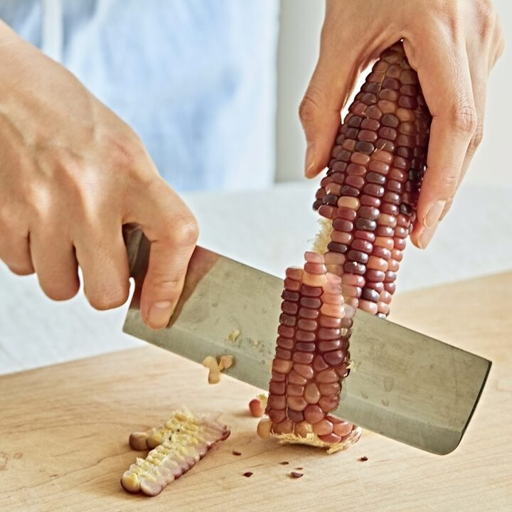

2. 달군 팬에 버터를 녹인 후 흑찰옥수수를 넣어 노릇하게 볶아주세요.

[figure not shown]

3. 마지막에 파마산치즈가루와 소금, 후춧가루, 딜을 넣어 완성해주세요.

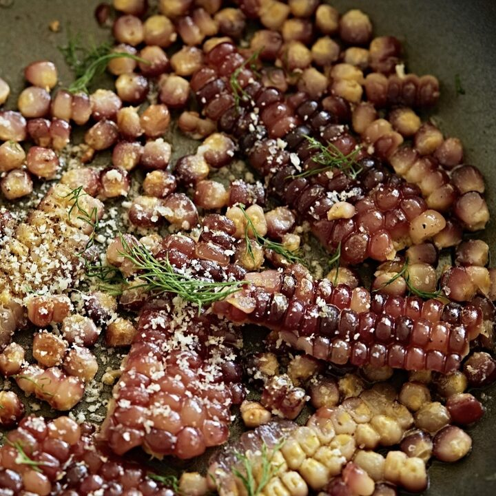

**무침 새송이버섯 들깨무침 재료 6가지 · 4단계 ＋**

재료

#### 기본 재료

- 새송이버섯 8개

#### 양념 재료

- 들깨가루 3큰술
- 간장 1큰술
- 액젓 1큰술
- 참기름 1큰술
- 통깨 약간

요리법

1. 새송이버섯은 필러로 슬라이스 해주세요.
2. 전자레인지용 그릇에 새송이버섯과 물 반컵을 넣어 2분 돌려주세요.
3. 버섯에서 나온 물은 버리고 한 김 식힌 후 양념 재료를 넣어 버무려주세요. (tip. 부족한 간은 소금으로 해주세요.)
4. 완성된 새송이버섯 들깨무침을 접시에 담아 밥과 함께 즐겨주세요.

**덮밥 가지 데리야키 덮밥 재료 14가지 · 3단계 ＋**

재료

#### 기본 재료

- 가지 2개
- 쪽파 2줄기
- 오일 적당량
- 통깨 약간
- 밥 2공기
- 전분 가루 1/2컵

#### 양념 재료

- 물 3큰술
- 간장 2큰술
- 맛술 1큰술
- 올리고당 1큰술
- 설탕 1/2큰술
- 다진 마늘 1작은술
- 생강즙 1작은술
- 후춧가루 약간

요리법

1. 가지는 한 입 크기로 잘라 전분 가루에 가볍게 묻혀주세요. 쪽파는 어슷하게 잘라주세요.
2. 달군 팬에 오일을 두른 후 전분을 묻힌 가지를 넣어 노릇하게 구워주세요.
3. 다른 팬에 양념 재료를 넣어 바글바글 끓으면 구운 가지를 넣어 가볍게 섞어주세요.

**솥밥 들깨 미역 무솥밥 재료 19가지 · 5단계 ＋**

재료

#### 기본 재료

- 쌀 250g
- 다시마육수 300ml
- 건미역 10g
- 무 100g
- 양파 70g
- 표고 3개

#### 솥밥 양념 재료

- 다진마늘 1큰술
- 다진 양파 1큰술
- 올리브오일 1큰술
- 들기름 1큰술
- 통깨 1큰술
- 들깨가루 2큰술
- 쯔유 1큰술

#### 곁들임 양념장 재료

- 진간장 3큰술
- 물 1큰술
- 다진마늘 1큰술
- 매실액 1큰술
- 통깨(빻아서) 1큰술
- 참기름 1/2큰술

요리법

1. 쌀은 깨끗이 씻어 물기를 빼고 30분 정도 불려주세요. 미역은 물에 30분 정도 불린 후 흐르는 물에 3~4번 씻어 물기를 빼고 잘게 다져 준비해 주세요.
2. 무는 얇게 깍뚝 썰어주세요. 양파는 잘게 다지고, 표고버섯도 얇게 썰어 준비해 주세요.
3. 솥에 올리브오일을 두르고, 다진 마늘과 다진 양파, 미역, 쯔유를 넣고 약불에서 살짝 볶아주세요.
4. 솥에 무, 불린쌀, 다시마 육수를 넣고 중불에서 끓여주세요. 끓기 시작하면 바닥까지 저어준 후, 들깨가루를 넣고 자른 버섯을 넣고 뚜껑을 닫고 약불에서 8분 정도 밥을 지어주세요.
5. 8분 후 불을 끄고 10분 정도 뜸 들여 주세요. 마지막에 들기름과 깨를 넣고 마무리 해 주세요. 곁들임 양념장과 함께 섞어 맛있게 즐겨주세요.

**국수 땡초 비빔국수 재료 5가지 · 3단계 ＋**

재료

#### 기본 재료

- 땡초장 6큰술
- 중면(또는 소면) 200g
- 송송 썬 쪽파(생략 가능) 약간
- 통깨 약간
- 참기름 약간

요리법

1. 끓는 물에 중면을 펼쳐 넣고, 면끼리 달라붙지 않도록 젓가락으로 저어주세요. 물이 끓어오르면 찬물 반 컵을 3~4회 반복해서 부어 국수를 삶아주세요.
2. 흐르는 찬물에 중면을 여러 번 씻어 전분기를 없애고, 채반에 받쳐 물기를 빼주세요.
3. 그릇에 면을 담은 후 땡초장을 올려주세요. 쪽파와 깨, 참기름을 뿌려 완성해주세요. (tip. 기호에 따라 삶은 달걀과 부추, 양배추 등의 채소를 추가로 넣어 드셔도 좋아요.)

**조림 생선 조림 재료 15가지 · 3단계 ＋**

재료

#### 기본 재료

- 생선(조림용) 적당량
- 물 800ml
- 무 취향대로
- 양파 취향대로
- 청양고추 취향대로
- 육수팩

#### 양념 재료 (B)

- 간장 5큰술
- 굴소스 2큰술
- 설탕 3큰술
- 고춧가루 4큰술
- 식초 1큰술
- 된장 1큰술
- 후추 약간
- 다진 마늘 2큰술
- 생강 1/2큰술

요리법

1. 무, 물 800ml, 육수팩을 넣어 무가 익을 때까지 끓여주세요.
2. 무 위에 생선을 올리고 양파, (B)의 재료를 넣어 섞어주세요.
3. 끓이면 완성.

**무침 콩나물 어묵 무침 재료 11가지 · 4단계 ＋**

재료

#### 기본 재료

- 콩나물 200g
- 어묵 100g
- 버섯 취향대로
- 파 약간
- 물 종이컵 1컵

#### 양념 재료

- 고춧가루 3큰술
- 진간장 2큰술
- 다진 마늘 1큰술
- 올리고당 1큰술
- 참치액젓 1/2큰술
- 후추 약간

요리법

1. 어묵을 한입 크기로, 야채는 적당한 크기로 잘라주세요.
2. 양념 재료를 다 섞어주세요.
3. 냄비에 콩나물을 깔고 어묵, 버섯, 파, 물의 순으로 넣고 뚜껑을 닫아주세요.
4. 콩나물이 살짝 익으면 양념을 넣어 섞어주세요. 전분을 넣어 농도를 맞춰도 됩니다. 양념이 야채에 배면 완성. 토핑으로 깻잎을 올려도 됩니다.

**무침 차돌박이 부추 무침 재료 12가지 · 5단계 ＋**

재료

#### 기본 재료 (3인분 기준)

- 차돌박이 200g
- 부추 100g
- 양파 1/2개
- 홍고추 1개
- 통깨 1큰술
- 소금 약간
- 후추 약간

#### 양념 재료

- 고춧가루 1큰술
- 간장 2큰술
- 식초 2큰술
- 매실청 1큰술
- 들기름 1큰술

요리법

1. 부추를 3cm 크기로, 양파와 홍고추를 얇게 잘라주세요.
2. 기름 없이 고기를 올려 소금 후추를 뿌려 구워주세요.
3. 휴지 위에 올려 기름기를 없애주세요.
4. 부추와 양파, 양념을 그릇에 넣어 가볍게 섞어주세요.
5. 고기와 홍고추, 깨를 뿌려 완성.

**사진 준비중무침 오이 두반장 무침 재료 10가지 · 6단계 ＋**

재료

#### 기본 재료

- 오이 2개
- 소금 1큰술
- 물 300ml

#### 양념 재료

- 쪽파 5대
- 설탕 1큰술
- 진간장 1/2큰술
- 식초 1/2큰술
- 두반장 1/2큰술
- 참기름 1큰술
- 참깨 1/2큰술

요리법

1. 오이 껍질을 벗겨주세요.
2. 오이를 적당한 크기로 잘라주세요.
3. 오이를 소금물(소금+물 300ml)에 최소 5분 절여주세요. 5분 뒤 채망으로 물기를 빼주세요.
4. 쪽파를 썰어주세요.
5. 썰어준 쪽파와 양념 재료를 섞어주세요.
6. 양념과 오이를 섞어주면 완성.

**국수 김치 비빔국수 재료 12가지 · 5단계 ＋**

재료

#### 기본 재료 (2인분)

- 신김치 2컵
- 면 200g
- 오이 1/2개
- 깨 약간

#### 양념 재료

- 고추장 2큰술
- 식초 2큰술
- 올리고당 2큰술
- 간장 1큰술
- 설탕 1큰술
- 맛술 1큰술
- 참기름 1큰술
- 후추 약간

요리법

1. 오이는 가늘게 썰고 김치는 굵게 다져주세요.
2. 볼에 다진 김치와 양념 재료를 넣고 섞어주세요.
3. 끓는 물에 중면을 펼쳐 넣고 면끼리 달라붙지 않도록 저어주세요. 물이 끓어오르면 찬물을 2~3회 반복해서 부어 국수를 삶아주세요. 흐르는 찬물에 면을 여러 번 씻어 전분기를 없애고 채반에 밭쳐 물기를 빼주세요.
4. 양념장에 삶은 국수를 넣고 버무려주세요.
5. 접시에 비빔국수를 담고 삶은 달걀과 오이채, 깨를 올려주면 완성.

**찜 김치 말이 두부찜 재료 14가지 · 5단계 ＋**

재료

#### 기본 재료 (3~4인분)

- 신김치 1/2포기
- 두부 1모
- 느타리 100g
- 양파 1/2개
- 대파 1/2대
- 채수 2+1/2컵
- 들기름 2큰술

#### 양념 재료

- 국간장 1큰술
- 된장 1/2큰술
- 고춧가루 1큰술
- 김치국물 1/3컵
- 다진 마늘 1큰술
- 설탕 1작은술
- 후춧가루 약간

요리법

1. 양파는 굵게 채 썰고, 대파는 어슷하게 썰어주세요. 느타리버섯은 밑동을 자르고 먹기 좋게 찢고, 두부는 손가락 두께로 잘라주세요. 볼에 양념 재료를 넣고 섞어주세요. (tip. 김치의 염도에 따라 김치 국물의 양을 가감해 주세요.)
2. 달군 팬에 들기름 1큰술을 두르고 두부를 돌려가며 노릇하게 구워주세요.
3. 김치를 넓게 깔고, 구운 두부를 올려 돌돌 말아주세요.
4. 냄비에 들기름 1큰술을 두르고 대파(1/2분량)를 넣어 볶다가 파의 향이 올라오면 느타리버섯과 양파를 넣어 볶아주세요. (tip. 김치말이두부의 이음새 부분이 냄비 바닥으로 가도록 놓아야 풀리지 않아요. 채수를 넣을 때는 냄비 가장자리부터 천천히 부어주세요. 기호에 따라 끓이는 중간에 채수를 가감해 국물의 양을 조절해 주세요.)
5. 김치가 부드럽게 익으면 기호에 따라 부족한 간을 소금으로 조절한 후 나머지 대파 반을 올려 맛있게 즐겨주세요.

**수프 토마토 수프 재료 14가지 · 6단계 ＋**

재료

#### 기본 재료 (2인분)

- 완숙 토마토 4개(800g)
- 양파 1/2개
- 당근 1/4개
- 다진 마늘 1/2큰술
- 바질 가루(생략 가능) 약간
- 월계수잎(생략 가능) 1장
- 버터 2큰술
- 치킨스톡(고형) 1조각
- 물 400ml
- 파슬리(생략 가능) 약간
- 소금 약간
- 후추 약간
- 파르메산 치즈 약간
- 올리브오일 약간

요리법

1. 깨끗이 씻은 토마토는 4~6등분으로 자르고 양파는 채 썰고 당근은 깍뚝 썰어주세요. 파슬리는 잘게 다져주세요.
2. 달군 냄비에 버터를 녹인 후 다진 마늘과 양파를 넣어 양파가 투명해질 때까지 3~5분 정도 볶아주세요.
3. 토마토와 당근을 넣어 3~4분 볶다가 뜨거운 물에 치킨스톡을 넣어 녹이고, 월계수잎과 바질가루를 함께 넣어 주세요. 중약불에서 뭉근하게 10~15분 끓인 후, 불을 끄고 월계수잎을 건져주세요.
4. 끓인 재료를 블렌더로 갈아준 후 5~10분 정도 더 끓여주세요.
5. 바게트와 크루통을 프라이팬에 바삭하게 구워주세요.
6. 수프를 담아 후추와 다진 파슬리를 뿌려주세요. 치즈그라인더로 치즈를 갈아 수프 위에 뿌리고 크루통을 올려주세요.